## 分析流程

1.导入数据  
2.变量说明  
3.数据预处理/数据清洗（重复值、缺失值、异常值处理）  
4.可视化分析（流失客户占比、基本特征对客户流失的影响、业务特征对客户流失的影响、合约特征对客户流失的影响）  
5.特征工程（特征提取、特征选择）  
6.模型预测（类别不平衡问题、交叉验证）  
7.模型评估  
8.分析决策（用户画像、结合模型）

# 一、导入数据

```python
import numpy as np
import pandas as pd
import warnings
warnings.filterwarnings('ignore') #  忽略弹出的warnings信息
```

```python
data = pd.read_csv('C:/Users/Administrator/Desktop/Telco-Customer-Churn.csv')
```

```python
data.head()
```

|  | customerID | gender | SeniorCitizen | Partner | Dependents | tenure | PhoneService | MultipleLines | InternetService | OnlineSecurity | OnlineBackup | DeviceProtection | TechSupport | StreamingTV | StreamingMovies | Contract | PaperlessBilling | PaymentMethod | MonthlyCharges | TotalCharges | Churn |
| --- | --- | --- | --- | --- | --- | --- | --- | --- | --- | --- | --- | --- | --- | --- | --- | --- | --- | --- | --- | --- | --- |
| 0 | 7590-VHVEG | Female | 0 | Yes | No | 1 | No | No phone service | DSL | No | Yes | No | No | No | No | Month-to-month | Yes | Electronic check | 29.85 | 29.85 | No |
| 1 | 5575-GNVDE | Male | 0 | No | No | 34 | Yes | No | DSL | Yes | No | Yes | No | No | No | One year | No | Mailed check | 56.95 | 1889.5 | No |
| 2 | 3668-QPYBK | Male | 0 | No | No | 2 | Yes | No | DSL | Yes | Yes | No | No | No | No | Month-to-month | Yes | Mailed check | 53.85 | 108.15 | Yes |
| 3 | 7795-CFOCW | Male | 0 | No | No | 45 | No | No phone service | DSL | Yes | No | Yes | Yes | No | No | One year | No | Bank transfer (automatic) | 42.30 | 1840.75 | No |
| 4 | 9237-HQITU | Female | 0 | No | No | 2 | Yes | No | Fiber optic | No | No | No | No | No | No | Month-to-month | Yes | Electronic check | 70.70 | 151.65 | Yes |

```python
#显示所有列（如果不设置会有列被隐藏掉，如上），第二个参数是显示的列数。如果是行：display.max_rows
pd.set_option('display.max_columns',None)
#--------------
#显示小数位数
#pd.set_option('display.float_format',lambda x: '%.2f'%x) #两位
#显示宽度
#pd.set_option('display.width', 100)
```

```python
data.head(5)
```

|  | customerID | gender | SeniorCitizen | Partner | Dependents | tenure | PhoneService | MultipleLines | InternetService | OnlineSecurity | OnlineBackup | DeviceProtection | TechSupport | StreamingTV | StreamingMovies | Contract | PaperlessBilling | PaymentMethod | MonthlyCharges | TotalCharges | Churn |
| --- | --- | --- | --- | --- | --- | --- | --- | --- | --- | --- | --- | --- | --- | --- | --- | --- | --- | --- | --- | --- | --- |
| 0 | 7590-VHVEG | Female | 0 | Yes | No | 1 | No | No phone service | DSL | No | Yes | No | No | No | No | Month-to-month | Yes | Electronic check | 29.85 | 29.85 | No |
| 1 | 5575-GNVDE | Male | 0 | No | No | 34 | Yes | No | DSL | Yes | No | Yes | No | No | No | One year | No | Mailed check | 56.95 | 1889.5 | No |
| 2 | 3668-QPYBK | Male | 0 | No | No | 2 | Yes | No | DSL | Yes | Yes | No | No | No | No | Month-to-month | Yes | Mailed check | 53.85 | 108.15 | Yes |
| 3 | 7795-CFOCW | Male | 0 | No | No | 45 | No | No phone service | DSL | Yes | No | Yes | Yes | No | No | One year | No | Bank transfer (automatic) | 42.30 | 1840.75 | No |
| 4 | 9237-HQITU | Female | 0 | No | No | 2 | Yes | No | Fiber optic | No | No | No | No | No | No | Month-to-month | Yes | Electronic check | 70.70 | 151.65 | Yes |

# 二、变量说明

#### 基本信息

1.customerID-----客户ID-----字符串  
2.gender---------性别-------字符串-------male/female  
3.SeniorCitizen---是否为老年人-------整型-----1/0  
4.Partner------是否有配偶-------字符串------yes/no  
5.Dependents---是否有家属-------字符串------yes/no  
6.tenure-------入月网数-------整型-----0-72

#### 开通业务信息

1.PhoneService----是否开通电话业务----字符串----yes/no  
2.MultipleLines-----是否开通多线业务----字符串----yes/no/No phone service  
3.InternetService---是否开通互联网业务----字符串----DSL/Fiber optic/no  
4.OnlineSecurity---是否开通在线安全业务----字符串----yes/no/No internet service  
5.OnlineBackup---是否开通在线备份业务----字符串----yes/no/No internet service  
6.DeviceProtection---是否开通设备保护业务----字符串----yes/no/No internet service  
7.TechSupport---是否开通技术支持业务----字符串----yes/no/No internet service  
8.StreamingTV---是否开通网络电视业务----字符串----yes/no/No internet service  
9.StreamingMovies---是否开通网络电影业务----字符串----yes/no/No internet service

#### 签署合约信息

1.Contract----合约期限----字符串-----Month-to-month/One year/Two year  
2.PaperlessBilling----是否采用电子结算----字符串-----Yes/No  
3.PaymentMethod-----付款方式-----字符串-----Electronic check/Mailed check/Bank transfer (automatic)/Credit card (automatic)  
4.MonthlyCharges----每月费用-----浮点型-----18.25-118.75  
5.TotalCharges----总费用-----字符串-----？有空格

#### 目标变量

Churn-----客户是否流失-----字符串------Yes/No

# 三、数据预处理

#### 1.重复值处理

```python
#检查是否有重复值

#DataFrame.drop_duplicates(subset=None, keep='first', inplace=False)
#第一个参数是指定列，subset=['TotalCharges']就限制了某一列。
#第二个参数表示保留第一次出现的重复行，是默认值。keep另外两个取值为"last"和False，分别表示保留最后一次出现的重复行和去除所有重复行。
#第三个参数表示直接在原来的DataFrame上删除重复项，而默认值False表示生成一个副本。

#data.shape[0]#返回行数

print("数据集中有%s个重复值" % (data.shape[0]-data.drop_duplicates().shape[0]))
```

```
数据集中有0个重复值
```

#### 2.缺失值处理

```python
#isnull()形成一个大矩阵，any()判断哪一列存在缺失值(返回是否至少一个元素为真)
#any()一个序列中满足一个True，则返回True；all()一个序列中所有值为True时，返回True，否则为False。
data.isnull().any()
```

```
customerID          False
gender              False
SeniorCitizen       False
Partner             False
Dependents          False
tenure              False
PhoneService        False
MultipleLines       False
InternetService     False
OnlineSecurity      False
OnlineBackup        False
DeviceProtection    False
TechSupport         False
StreamingTV         False
StreamingMovies     False
Contract            False
PaperlessBilling    False
PaymentMethod       False
MonthlyCharges      False
TotalCharges        False
Churn               False
dtype: bool
```

虽然没有缺失值，但是可能会采用“Null”“NaN”这样的字符串来表示缺失。比如TotalCharges这一列，有用空格来表示缺失值。

```python
# 查看TotalCharges的缺失值
data[data['TotalCharges'] == ' ']
```

|  | customerID | gender | SeniorCitizen | Partner | Dependents | tenure | PhoneService | MultipleLines | InternetService | OnlineSecurity | OnlineBackup | DeviceProtection | TechSupport | StreamingTV | StreamingMovies | Contract | PaperlessBilling | PaymentMethod | MonthlyCharges | TotalCharges | Churn |
| --- | --- | --- | --- | --- | --- | --- | --- | --- | --- | --- | --- | --- | --- | --- | --- | --- | --- | --- | --- | --- | --- |
| 488 | 4472-LVYGI | Female | 0 | Yes | Yes | 0 | No | No phone service | DSL | Yes | No | Yes | Yes | Yes | No | Two year | Yes | Bank transfer (automatic) | 52.55 |  | No |
| 753 | 3115-CZMZD | Male | 0 | No | Yes | 0 | Yes | No | No | No internet service | No internet service | No internet service | No internet service | No internet service | No internet service | Two year | No | Mailed check | 20.25 |  | No |
| 936 | 5709-LVOEQ | Female | 0 | Yes | Yes | 0 | Yes | No | DSL | Yes | Yes | Yes | No | Yes | Yes | Two year | No | Mailed check | 80.85 |  | No |
| 1082 | 4367-NUYAO | Male | 0 | Yes | Yes | 0 | Yes | Yes | No | No internet service | No internet service | No internet service | No internet service | No internet service | No internet service | Two year | No | Mailed check | 25.75 |  | No |
| 1340 | 1371-DWPAZ | Female | 0 | Yes | Yes | 0 | No | No phone service | DSL | Yes | Yes | Yes | Yes | Yes | No | Two year | No | Credit card (automatic) | 56.05 |  | No |
| 3331 | 7644-OMVMY | Male | 0 | Yes | Yes | 0 | Yes | No | No | No internet service | No internet service | No internet service | No internet service | No internet service | No internet service | Two year | No | Mailed check | 19.85 |  | No |
| 3826 | 3213-VVOLG | Male | 0 | Yes | Yes | 0 | Yes | Yes | No | No internet service | No internet service | No internet service | No internet service | No internet service | No internet service | Two year | No | Mailed check | 25.35 |  | No |
| 4380 | 2520-SGTTA | Female | 0 | Yes | Yes | 0 | Yes | No | No | No internet service | No internet service | No internet service | No internet service | No internet service | No internet service | Two year | No | Mailed check | 20.00 |  | No |
| 5218 | 2923-ARZLG | Male | 0 | Yes | Yes | 0 | Yes | No | No | No internet service | No internet service | No internet service | No internet service | No internet service | No internet service | One year | Yes | Mailed check | 19.70 |  | No |
| 6670 | 4075-WKNIU | Female | 0 | Yes | Yes | 0 | Yes | Yes | DSL | No | Yes | Yes | Yes | Yes | No | Two year | No | Mailed check | 73.35 |  | No |
| 6754 | 2775-SEFEE | Male | 0 | No | Yes | 0 | Yes | Yes | DSL | Yes | Yes | No | Yes | No | No | Two year | Yes | Bank transfer (automatic) | 61.90 |  | No |

```python
data.info()
```

```
<class 'pandas.core.frame.DataFrame'>
RangeIndex: 7043 entries, 0 to 7042
Data columns (total 21 columns):
customerID          7043 non-null object
gender              7043 non-null object
SeniorCitizen       7043 non-null int64
Partner             7043 non-null object
Dependents          7043 non-null object
tenure              7043 non-null int64
PhoneService        7043 non-null object
MultipleLines       7043 non-null object
InternetService     7043 non-null object
OnlineSecurity      7043 non-null object
OnlineBackup        7043 non-null object
DeviceProtection    7043 non-null object
TechSupport         7043 non-null object
StreamingTV         7043 non-null object
StreamingMovies     7043 non-null object
Contract            7043 non-null object
PaperlessBilling    7043 non-null object
PaymentMethod       7043 non-null object
MonthlyCharges      7043 non-null float64
TotalCharges        7043 non-null object
Churn               7043 non-null object
dtypes: float64(1), int64(2), object(18)
memory usage: 1.1+ MB
```

TotalCharges这一列虽然是字符串，但是实际上应该是浮点型，因为本身是数值变量，浮点型比字符串研究起来更方便。在这里我们转换为浮点型，对于不可转换的空格缺失值，我们将其转换为标准的数值缺失值NaN。

```python
#  数值转换：pd.to_numeric
#pd.to_numeric(s, errors='raise') # 遇到非数字字符串类型报错,bool类型报错,时间类型转换为int
#pd.to_numeric(s, errors='ignore') # 只对数字字符串转换,其他类型一律不转换,包含时间类型
#pd.to_numeric(s, errors='coerce')  # 将时间字符串和bool类型转换为数字,其他均转换为NaN

data['TotalCharges'] = data['TotalCharges'].apply(pd.to_numeric, errors='coerce')

print("此时TotalCharges是否已经转换为浮点型：", data['TotalCharges'].dtype == 'float')
print("此时TotalCharges存在%s行缺失样本。" % data['TotalCharges'].isnull().sum())
```

```
此时TotalCharges是否已经转换为浮点型： True
此时TotalCharges存在11行缺失样本。
```

可以看到这一列是有缺失值的。 其他处理缺失值的方案：  
1.删除缺失值。dropna(axis=0,how='any') axis=0指的是按行，how='all'指的是这一行所有值都是NA才会被删除，如果是'any'则是存在就删除。  
2.补充缺失值。  
DataFrame.fillna(value=None, method=None, axis=None, inplace=False)  
-value: 变量、字典、Series，DataFrame；用于填充填充缺失值，或指定为每个索引（对于Series）或列（对于DataFrame）的缺失值使用字典/Series/DataFrame的值填充  
-method: {'backfill', 'bfill', 'pad', 'ffill', None}, 默认None， pad/ffill表示向后填充空值，backfill/bfill表示向前填充空值  
-axis: {0 or 'index', 1 or 'columns'}  
-inplace: boolean, 默认为False。若为True， 在原地填满

数值型变量一般用固定值填充，如果这里缺失值用0填充：

```python
data1 = data['TotalCharges'].fillna(0).to_frame()  #.to_frame()将数组转化为dataframe格式
```

```python
data1.isnull().sum()
```

```
TotalCharges    0
dtype: int64
```

但是既然每月费用并不为0，那么总费用不应该是0.我们进一步观察这些有缺失值的数据，发现tenure（入网月数）均为0.

```python
data[data['TotalCharges'].isnull()==True].head(5)
```

|  | customerID | gender | SeniorCitizen | Partner | Dependents | tenure | PhoneService | MultipleLines | InternetService | OnlineSecurity | OnlineBackup | DeviceProtection | TechSupport | StreamingTV | StreamingMovies | Contract | PaperlessBilling | PaymentMethod | MonthlyCharges | TotalCharges | Churn |
| --- | --- | --- | --- | --- | --- | --- | --- | --- | --- | --- | --- | --- | --- | --- | --- | --- | --- | --- | --- | --- | --- |
| 488 | 4472-LVYGI | Female | 0 | Yes | Yes | 0 | No | No phone service | DSL | Yes | No | Yes | Yes | Yes | No | Two year | Yes | Bank transfer (automatic) | 52.55 | NaN | No |
| 753 | 3115-CZMZD | Male | 0 | No | Yes | 0 | Yes | No | No | No internet service | No internet service | No internet service | No internet service | No internet service | No internet service | Two year | No | Mailed check | 20.25 | NaN | No |
| 936 | 5709-LVOEQ | Female | 0 | Yes | Yes | 0 | Yes | No | DSL | Yes | Yes | Yes | No | Yes | Yes | Two year | No | Mailed check | 80.85 | NaN | No |
| 1082 | 4367-NUYAO | Male | 0 | Yes | Yes | 0 | Yes | Yes | No | No internet service | No internet service | No internet service | No internet service | No internet service | No internet service | Two year | No | Mailed check | 25.75 | NaN | No |
| 1340 | 1371-DWPAZ | Female | 0 | Yes | Yes | 0 | No | No phone service | DSL | Yes | Yes | Yes | Yes | Yes | No | Two year | No | Credit card (automatic) | 56.05 | NaN | No |

并且发现总费用没有缺失值的数据中tenure均不为0，可知这两个数据是对应的，在实际业务中考虑，这些样本对应的客户可能入网当月就流失了，但仍然要收取当月的费用。所以这里我们直接用每月费用填充总费用的缺失值。

```python
data['TotalCharges'] = data['TotalCharges'].fillna(data['MonthlyCharges'])
```

```python
print("此时TotalCharges存在%s行缺失样本。" % data['TotalCharges'].isnull().sum())
```

```
此时TotalCharges存在0行缺失样本。
```

#### 3.异常值处理

```python
#查看数值类数据的统计特征
data.describe()
```

|  | SeniorCitizen | tenure | MonthlyCharges | TotalCharges |
| --- | --- | --- | --- | --- |
| count | 7043.000000 | 7043.000000 | 7043.000000 | 7043.000000 |
| mean | 0.162147 | 32.371149 | 64.761692 | 2279.798992 |
| std | 0.368612 | 24.559481 | 30.090047 | 2266.730170 |
| min | 0.000000 | 0.000000 | 18.250000 | 18.800000 |
| 25% | 0.000000 | 9.000000 | 35.500000 | 398.550000 |
| 50% | 0.000000 | 29.000000 | 70.350000 | 1394.550000 |
| 75% | 0.000000 | 55.000000 | 89.850000 | 3786.600000 |
| max | 1.000000 | 72.000000 | 118.750000 | 8684.800000 |

SeniorCitizen--是否为老年人只有1和0两个值，所以也视为类别特征而非数值特征。因此只有tenure、MonthlyCharges及经过处理的TotalCharges是数值特征。  
我们结合箱型图进行观察：

```python
import seaborn as sns
import matplotlib.pyplot as plt
```

```python
#在jupyter里嵌入图片
%matplotlib inline
```

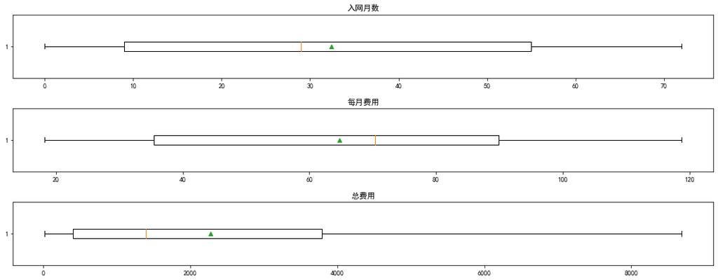

```python
plt.rcParams["font.sans-serif"]=["SimHei"] #设置字体
plt.rcParams["axes.unicode_minus"]=False #该语句解决图像中的“-”负号的乱码问题

# 分析百分比特征
fig = plt.figure(figsize=(15,6)) # 建立图像

####boxplot(list1, vert=False, showmeans=True, flierprops = {"marker":"o","markerfacecolor":"steelblue"})
####第一个参数是数据，vert=False是否需要将箱线图垂直摆放，默认垂直摆放；showmeans=True是否显示均值，默认不显示；
####flierprops = {'marker':'异常点形状', 'color':'异常点边框色', 'markerfacecolor':'异常点颜色'}

# tenure特征
ax1 = fig.add_subplot(311)    # 子图1
list1 = list(data['tenure'])
ax1.boxplot(list1, vert=False, showmeans=True, flierprops = {"marker":"o","markerfacecolor":"steelblue"})
ax1.set_title('入网月数')

# MonthlyCharges特征
ax2 = fig.add_subplot(312)    # 子图2
list2 = list(data['MonthlyCharges'])
ax2.boxplot(list2, vert=False, showmeans=True, flierprops = {"marker":"o","markerfacecolor":"steelblue"})
ax2.set_title('每月费用')

# TotalCharges
ax3 = fig.add_subplot(313)    # 子图3
list3 = list(data['TotalCharges'])
ax3.boxplot(list3, vert=False, showmeans=True, flierprops = {"marker":"o","markerfacecolor":"steelblue"})
ax3.set_title('总费用')

plt.tight_layout(pad=1.5)    # 设置子图之间的间距
plt.show() # 展示箱型图
```

如果采用箱线图识别异常值，其判断标准是，当变量的数据值大于箱线图的上须或者小于箱线图的下须时，就可以认为这样的数据点为异常点。  
由箱型图我们可以看出这三个变量均不含异常点，因此不需要处理异常值。

# 四、可视化分析

#### 1.流失客户占比

```python
# 观察是否存在类别不平衡现象
p = data['Churn'].value_counts()    # 目标变量正负样本的分布，ascending=True为升序
```

```python
p
```

```
No     5174
Yes    1869
Name: Churn, dtype: int64
```

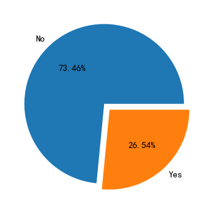

```python
plt.figure(figsize=(10,6))    # 构建图像

# 绘制饼图并调整字体大小，autopct格式化输出百分比
#返回值：patches：饼图上每个分块的对象。texts：分块的名字文本对象。autotexts：分块的比例文字对象。
patches, l_text, p_text = plt.pie(p,labels=['No','Yes'],autopct='%1.2f%%',explode=(0,0.1))
# l_text是饼图对着文字大小，p_text是饼图内文字大小
for t in p_text:
    t.set_size(15)
for t in l_text:
    t.set_size(15)

plt.show()    # 展示图像
```

由饼图可以看出流失人数占26.54%，存在类别不均衡现象，后续需要处理。

#### 2.基本特征对客户流失的影响

```python
data[['gender','SeniorCitizen','Partner','Dependents']].head(5)
```

|  | gender | SeniorCitizen | Partner | Dependents |
| --- | --- | --- | --- | --- |
| 0 | Female | 0 | Yes | No |
| 1 | Male | 0 | No | No |
| 2 | Male | 0 | No | No |
| 3 | Male | 0 | No | No |
| 4 | Female | 0 | No | No |

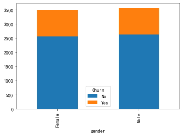

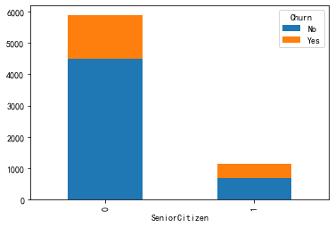

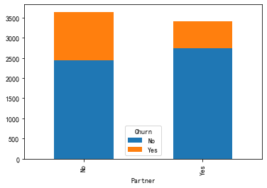

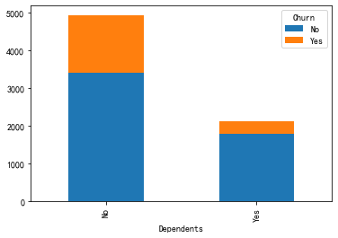

```python
### 性别、是否老年人、是否有配偶、是否有家属等特征对客户流失的影响
baseCols = ['gender','SeniorCitizen','Partner','Dependents']

for i in baseCols:
    cnt = pd.crosstab(data[i],data['Churn'])##交叉列联表
    cnt.plot.bar(stacked=True)    # 绘制堆叠条形图，便于观察不同特征值流失的占比情况，Stacked=True为堆积柱状图。
    plt.show()
```

从堆积图可以看出：性别对客户流失基本没有影响；是否老年人对客户流失有影响，老年人流失比例高于年轻人；无配偶客户流失占比高于有配偶客户；无家属客户流失占比高于有家属客户。

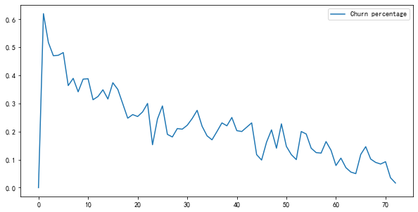

```python
### 观察流失率与入网月数的关系

# 折线图
groupDf = data[['tenure', 'Churn']]    # _入月网数_和_客户是否流失_ 字段
groupDf['Churn'] = groupDf['Churn'].map({'Yes': 1, 'No': 0})    # 字典映射，将正负样本目标变量改为1和0方便计算
pctDf = groupDf.groupby(['tenure']).sum() / groupDf.groupby(['tenure']).count()    # 计算不同入网月数对应的流失率
pctDf = pctDf.reset_index()    # reset_index()将索引变成列(重置索引)

plt.figure(figsize=(10, 5))
plt.plot(pctDf['tenure'], pctDf['Churn'], label='Churn percentage')    # 绘制折线图
plt.legend()    # 显示图例
plt.show()
```

由图可知：除了刚入网（tenure=0）的客户之外，流失率随着入网时间的延长呈下降趋势。即：入网时间越长，流失率越低。

#### 3.业务特征对客户流失的影响

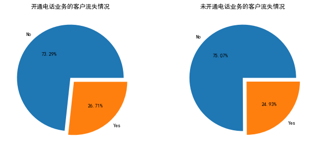

```python
##电话业务
yDf = data[data['PhoneService']=='Yes']
nDf = data[data['PhoneService']=='No']

fig = plt.figure(figsize = (10,4)) #建立图像

ax1 = fig.add_subplot(121)
p1 = yDf['Churn'].value_counts()
ax1.pie(p1,labels = ['No','Yes'],autopct='%1.2f%%',explode=(0,0.1))
ax1.set_title("开通电话业务的客户流失情况")

ax2 = fig.add_subplot(122)
p2 = nDf['Churn'].value_counts()
ax2.pie(p2,labels=['No','Yes'],autopct='%1.2f%%',explode=(0,0.1))
ax2.set_title('未开通电话业务的客户流失情况')

plt.tight_layout(pad=0.5)    # 设置子图之间的间距
plt.show() # 展示饼状图
```

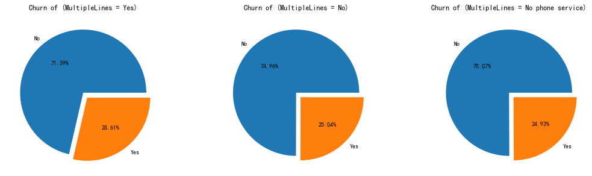

```python
# 多线业务
df1 = data[data['MultipleLines'] == 'Yes']
df2 = data[data['MultipleLines'] == 'No']
df3 = data[data['MultipleLines'] == 'No phone service']

fig = plt.figure(figsize=(15,4)) # 建立图像

ax1 = fig.add_subplot(131)
p1 = df1['Churn'].value_counts()
ax1.pie(p1,labels=['No','Yes'],autopct='%1.2f%%',explode=(0,0.1))
ax1.set_title('Churn of (MultipleLines = Yes)')

ax2 = fig.add_subplot(132)
p2 = df2['Churn'].value_counts()
ax2.pie(p2,labels=['No','Yes'],autopct='%1.2f%%',explode=(0,0.1))
ax2.set_title('Churn of (MultipleLines = No)')

ax3 = fig.add_subplot(133)
p3 = df3['Churn'].value_counts()
ax3.pie(p3,labels=['No','Yes'],autopct='%1.2f%%',explode=(0,0.1))
ax3.set_title('Churn of (MultipleLines = No phone service)')

plt.tight_layout(pad=0.5)    # 设置子图之间的间距
plt.show() # 展示饼状图
```

由图可知，是否开通电话业务、是否开通多线业务对客户流失影响很小。（没开通多线业务的两个选项情况差不多，两个后续可以合并）

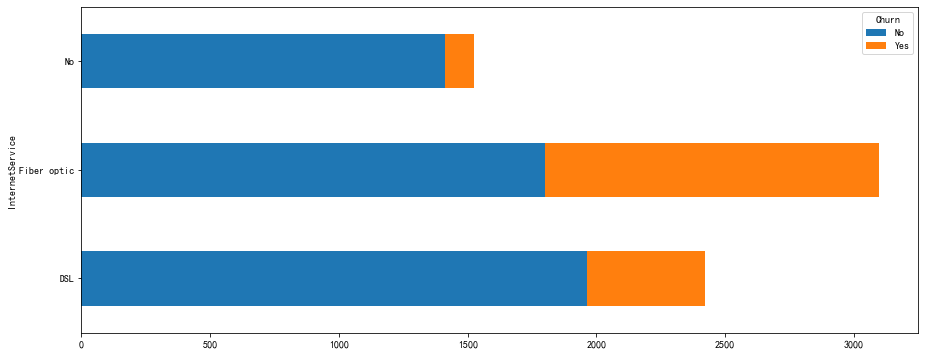

```python
# 互联网业务
cnt = pd.crosstab(data['InternetService'], data['Churn'])    # 构建特征与目标变量的列联表
cnt.plot.barh(stacked=True, figsize=(15,6))    # 绘制堆叠条形图，便于观察不同特征值流失的占比情况（barh是水平直方图）
plt.show()    # 展示图像
```

```python
cnt['rate'] = cnt['Yes']/(cnt['Yes']+cnt['No'])
```

```python
cnt
```

| Churn InternetService | No | Yes | rate |
| --- | --- | --- | --- |
| DSL | 1962 | 459 | 0.189591 |
| Fiber optic | 1799 | 1297 | 0.418928 |
| No | 1413 | 113 | 0.074050 |

没开通互联网服务的客户总数最少，而客户流失比例也最少，为7.4%左右；  
开通光纤服务的客户总数最多，而客户流失比例也最大，为41.9%左右；  
开通数字网络的客户总数居中，流失比例居中，为19%左右。

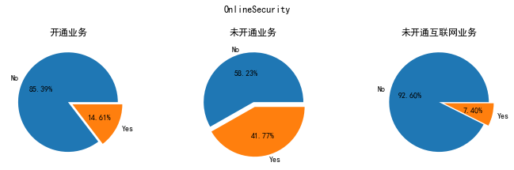

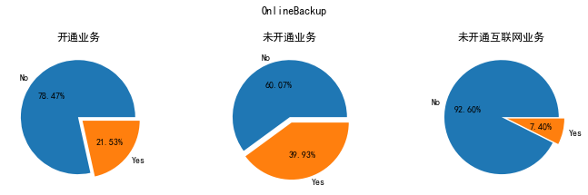

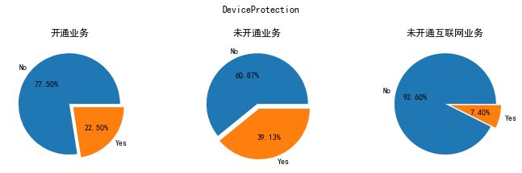

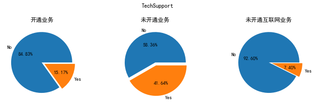

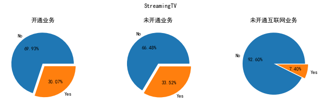

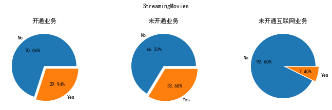

```python
# 与互联网相关的业务
internetCols = ['OnlineSecurity', 'OnlineBackup', 'DeviceProtection', 'TechSupport', 'StreamingTV', 'StreamingMovies']

for i in internetCols:
    df1 = data[data[i] == 'Yes']
    df2 = data[data[i] == 'No']
    df3 = data[data[i] == 'No internet service']

    fig = plt.figure(figsize=(10,3)) # 建立图像
    plt.suptitle(i)

    ax1 = fig.add_subplot(131)
    p1 = df1['Churn'].value_counts()
    ax1.pie(p1,labels=['No','Yes'],autopct='%1.2f%%',explode=(0,0.1))    # 开通业务
    plt.title('开通业务')

    ax2 = fig.add_subplot(132)
    p2 = df2['Churn'].value_counts()
    ax2.pie(p2,labels=['No','Yes'],autopct='%1.2f%%',explode=(0,0.1))    # 未开通业务
    plt.title('未开通业务')

    ax3 = fig.add_subplot(133)
    p3 = df3['Churn'].value_counts()
    ax3.pie(p3,labels=['No','Yes'],autopct='%1.2f%%',explode=(0,0.1))    # 未开通互联网业务
    plt.title('未开通互联网业务')

    plt.tight_layout(rect=(0,0,1,0.9))    # 设置子图之间的间距，使之不重叠
    plt.show() # 展示饼状图
```

由图可知：  
1.所有互联网相关业务中未开通互联网的客户流失率均为7.40%，可以判断原因是上述六列特征均只在客户开通互联网业务之后才有实际意义，因而不会影响未开通互联网的客户；  
2.开通了这些新业务之后，用户的流失率会有不同程度的降低，可以认为多绑定业务有助于用户的留存；  
3.'StreamingTV'和 'StreamingMovies'两列特征对客户流失基本没有影响。  
4.此外，由于 'No internet service' 也算是 'No' 的一种情况，因此后续步骤中可以考虑将两种特征值进行合并。

#### 4.合约特征对客户流失的影响

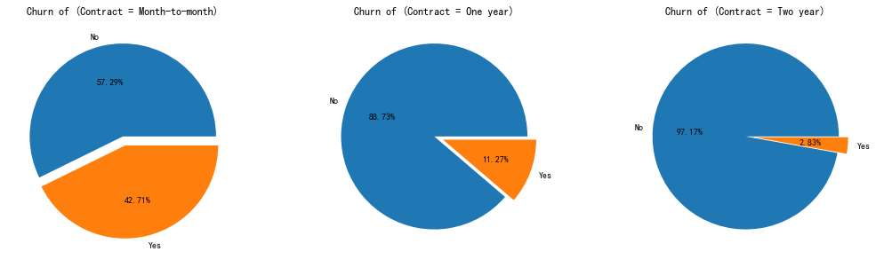

```python
# 合约期限
df1 = data[data['Contract'] == 'Month-to-month']
df2 = data[data['Contract'] == 'One year']
df3 = data[data['Contract'] == 'Two year']

fig = plt.figure(figsize=(15,4)) # 建立图像

ax1 = fig.add_subplot(131)
p1 = df1['Churn'].value_counts()
ax1.pie(p1,labels=['No','Yes'],autopct='%1.2f%%',explode=(0,0.1))
ax1.set_title('Churn of (Contract = Month-to-month)')

ax2 = fig.add_subplot(132)
p2 = df2['Churn'].value_counts()
ax2.pie(p2,labels=['No','Yes'],autopct='%1.2f%%',explode=(0,0.1))
ax2.set_title('Churn of (Contract = One year)')

ax3 = fig.add_subplot(133)
p3 = df3['Churn'].value_counts()
ax3.pie(p3,labels=['No','Yes'],autopct='%1.2f%%',explode=(0,0.1))
ax3.set_title('Churn of (Contract = Two year)')

plt.tight_layout(pad=0.5)    # 设置子图之间的间距
plt.show() # 展示饼状图
```

从图中可以看出，合约时间越长，用户流失比例越低。

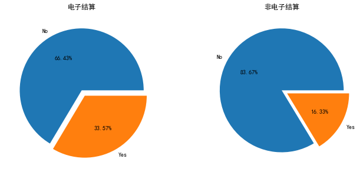

```python
# 是否采用电子结算
df1 = data[data['PaperlessBilling'] == 'Yes']
df2 = data[data['PaperlessBilling'] == 'No']

fig = plt.figure(figsize=(10,4)) # 建立图像

ax1 = fig.add_subplot(121)
p1 = df1['Churn'].value_counts()
ax1.pie(p1,labels=['No','Yes'],autopct='%1.2f%%',explode=(0,0.1))
ax1.set_title('电子结算')

ax2 = fig.add_subplot(122)
p2 = df2['Churn'].value_counts()
ax2.pie(p2,labels=['No','Yes'],autopct='%1.2f%%',explode=(0,0.1))
ax2.set_title('非电子结算')

plt.tight_layout(pad=0.5)    # 设置子图之间的间距
plt.show() # 展示饼状图
```

由图可知：采用电子结算的客户流失率较高，原因可能是电子结算多为按月支付的形式。

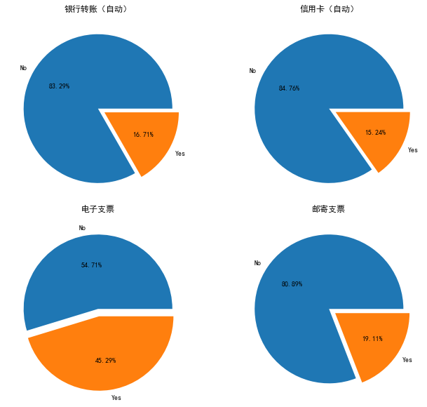

```python
# 付款方式
df1 = data[data['PaymentMethod'] == 'Bank transfer (automatic)']    # 银行转账（自动）
df2 = data[data['PaymentMethod'] == 'Credit card (automatic)']    # 信用卡（自动）
df3 = data[data['PaymentMethod'] == 'Electronic check']    # 电子支票
df4 = data[data['PaymentMethod'] == 'Mailed check']    # 邮寄支票

fig = plt.figure(figsize=(10,8)) # 建立图像

ax1 = fig.add_subplot(221)
p1 = df1['Churn'].value_counts()
ax1.pie(p1,labels=['No','Yes'],autopct='%1.2f%%',explode=(0,0.1))
ax1.set_title('银行转账（自动）')

ax2 = fig.add_subplot(222)
p2 = df2['Churn'].value_counts()
ax2.pie(p2,labels=['No','Yes'],autopct='%1.2f%%',explode=(0,0.1))
ax2.set_title('信用卡（自动）')

ax3 = fig.add_subplot(223)
p3 = df3['Churn'].value_counts()
ax3.pie(p3,labels=['No','Yes'],autopct='%1.2f%%',explode=(0,0.1))
ax3.set_title('电子支票')

ax4 = fig.add_subplot(224)
p4 = df4['Churn'].value_counts()
ax4.pie(p4,labels=['No','Yes'],autopct='%1.2f%%',explode=(0,0.1))
ax4.set_title('邮寄支票')

plt.tight_layout(pad=0.5)    # 设置子图之间的间距
plt.show() # 展示饼状图
```

由图可知：四种付款方式中采用电子支票的客户流失率远高于其他三种。

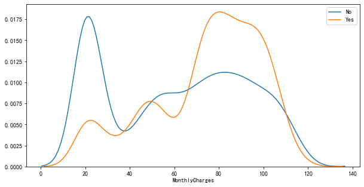

```python
# 每月费用核密度估计图
plt.figure(figsize=(10, 5))    # 构建图像

#hist=False不显示直方图，kde=False不显示核密度。

negDf = data[data['Churn'] == 'No']
sns.distplot(negDf['MonthlyCharges'], hist=False, label= 'No')
posDf = data[data['Churn'] == 'Yes']
sns.distplot(posDf['MonthlyCharges'], hist=False, label= 'Yes')

plt.show()    # 展示图像
```

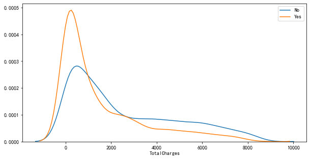

```python
# 总费用核密度估计图
plt.figure(figsize=(10, 5))    # 构建图像

negDf = data[data['Churn'] == 'No']
sns.distplot(negDf['TotalCharges'], hist=False, label= 'No')
posDf = data[data['Churn'] == 'Yes']
sns.distplot(posDf['TotalCharges'], hist=False, label= 'Yes')

plt.show()    # 展示图像
```

由图可知：客户的流失率的基本趋势是随每月费用的增加而增长，这与实际业务较为符合；  
当客户的总费用积累越多，流失率越低，这说明这些客户已经称为稳定的客户，不会轻易流失；  
此外，当每月费用处于70～110之间时流失率较高。

# 五、特征工程

### 1.特征提取

```python
### 数值特征标准化
from sklearn.preprocessing import StandardScaler    # 导入标准化库

###新版本的sklearn库要求输入数据是二维的，而例如data['tenure']这样的Series格式本质上是一维的
###如果直接进行标准化，可能报错 "ValueError: Expected 2D array, got 1D array instead"
###解决方法是变一维的Series为二维的DataFrame，即多加一组[]，例如data[['tenure']]
```

```python
scaler = StandardScaler()
data[['tenure']] = scaler.fit_transform(data[['tenure']])
data[['MonthlyCharges']] = scaler.fit_transform(data[['MonthlyCharges']])
data[['TotalCharges']] = scaler.fit_transform(data[['TotalCharges']])

data[['tenure', 'MonthlyCharges', 'TotalCharges']].head()    # 观察此时的数值特征

#将数值特征缩放到同一尺度下，避免对特征重要性产生误判。
```

|  | tenure | MonthlyCharges | TotalCharges |
| --- | --- | --- | --- |
| 0 | -1.277445 | -1.160323 | -0.992667 |
| 1 | 0.066327 | -0.259629 | -0.172198 |
| 2 | -1.236724 | -0.362660 | -0.958122 |
| 3 | 0.514251 | -0.746535 | -0.193706 |
| 4 | -1.236724 | 0.197365 | -0.938930 |

```python
### 类别特征编码
# 首先将部分特征值进行合并
#将MultipleLines这一列中为No phone service的全部设置为No
data.loc[data['MultipleLines']=='No phone service', 'MultipleLines'] = 'No'
#互联网业务中No internet service全部设置为No
internetCols = ['OnlineSecurity', 'OnlineBackup', 'DeviceProtection', 'TechSupport', 'StreamingTV', 'StreamingMovies']
for i in internetCols:
    data.loc[data[i]=='No internet service', i] = 'No'

print("MultipleLines特征还有%d条样本的值为 'No phone service'" % data[data['MultipleLines']=='No phone service'].shape[0])
print("OnlineSecurity特征还有%d条样本的值为 'No internet service'" % data[data['OnlineSecurity']=='No internet service'].shape[0])
print("OnlineBackup特征还有%d条样本的值为 'No internet service'" % data[data['OnlineBackup']=='No internet service'].shape[0])
print("DeviceProtection特征还有%d条样本的值为 'No internet service'" % data[data['DeviceProtection']=='No internet service'].shape[0])
print("TechSupport特征还有%d条样本的值为 'No internet service'" % data[data['TechSupport']=='No internet service'].shape[0])
print("StreamingTV特征还有%d条样本的值为 'No internet service'" % data[data['StreamingTV']=='No internet service'].shape[0])
print("StreamingMovies特征还有%d条样本的值为 'No internet service'" % data[data['StreamingMovies']=='No internet service'].shape[0])
```

```
MultipleLines特征还有0条样本的值为 'No phone service'
OnlineSecurity特征还有0条样本的值为 'No internet service'
OnlineBackup特征还有0条样本的值为 'No internet service'
DeviceProtection特征还有0条样本的值为 'No internet service'
TechSupport特征还有0条样本的值为 'No internet service'
StreamingTV特征还有0条样本的值为 'No internet service'
StreamingMovies特征还有0条样本的值为 'No internet service'
```

```python
# 部分类别特征只有两类取值，可以直接用0、1代替；另外，可视化过程中发现有四列特征对结果影响可以忽略，后续直接删除
# 选择特征值为‘Yes’和 'No' 的列名
encodeCols = list(data.columns[3: 17].drop(['tenure', 'PhoneService', 'InternetService', 'StreamingTV', 'StreamingMovies', 'Contract']))
for i in encodeCols:
    data[i] = data[i].map({'Yes': 1, 'No': 0})    # 用1代替'Yes’，0代替 'No'
# 顺便把目标变量也进行编码
data['Churn'] = data['Churn'].map({'Yes': 1, 'No': 0})
```

```python
# 其他无序的类别特征采用独热编码    （One-Hot Encoding）
#独热编码，又称一位有效编码，其方法是使用N位状态寄存器来对N个状态进行编码，
#每个状态都有它独立的寄存器位，并且在任意时候，其中只有一位有效。
#即，只有一位是1，其余都是零值。

#在回归，分类，聚类等机器学习算法中，特征之间距离的计算或相似度的计算是非常重要的。
#而常用的距离或相似度的计算都是在欧式空间的相似度计算，计算余弦相似性，基于的就是欧式空间。
#使用独热编码（One-Hot Encoding），将离散特征的取值扩展到了欧式空间，离散特征的某个取值就对应欧式空间的某个点。
#将离散型特征使用独热编码（One-Hot Encoding），会让特征之间的距离计算更加合理。

onehotCols = ['InternetService', 'Contract', 'PaymentMethod']
churnDf = data['Churn'].to_frame()    # 取出目标变量列，以便后续进行合并
featureDf = data.drop(['Churn'], axis=1)    # 所有特征列

#pandas.get_dummies(data, prefix=None, prefix_sep=’_’,dummy_na=False, columns=None, sparse=False, drop_first=False, dtype=None)
#prefix列名前缀

for i in onehotCols:
    onehotDf = pd.get_dummies(featureDf[i],prefix=i)
    featureDf = pd.concat([featureDf, onehotDf],axis=1)    # 编码后特征拼接到去除目标变量的数据集中

data = pd.concat([featureDf, churnDf],axis=1)    # 拼回目标变量，确保目标变量在最后一列
data = data.drop(onehotCols, axis=1)    # 删除原特征列
```

```python
data.head(5)
```

|  | customerID | gender | SeniorCitizen | Partner | Dependents | tenure | PhoneService | MultipleLines | OnlineSecurity | OnlineBackup | DeviceProtection | TechSupport | StreamingTV | StreamingMovies | PaperlessBilling | MonthlyCharges | TotalCharges | InternetService_DSL | InternetService_Fiber optic | InternetService_No | Contract_Month-to-month | Contract_One year | Contract_Two year | PaymentMethod_Bank transfer (automatic) | PaymentMethod_Credit card (automatic) | PaymentMethod_Electronic check | PaymentMethod_Mailed check | Churn |
| --- | --- | --- | --- | --- | --- | --- | --- | --- | --- | --- | --- | --- | --- | --- | --- | --- | --- | --- | --- | --- | --- | --- | --- | --- | --- | --- | --- | --- |
| 0 | 7590-VHVEG | Female | 0 | 1 | 0 | -1.277445 | No | 0 | 0 | 1 | 0 | 0 | No | No | 1 | -1.160323 | -0.992667 | 1 | 0 | 0 | 1 | 0 | 0 | 0 | 0 | 1 | 0 | 0 |
| 1 | 5575-GNVDE | Male | 0 | 0 | 0 | 0.066327 | Yes | 0 | 1 | 0 | 1 | 0 | No | No | 0 | -0.259629 | -0.172198 | 1 | 0 | 0 | 0 | 1 | 0 | 0 | 0 | 0 | 1 | 0 |
| 2 | 3668-QPYBK | Male | 0 | 0 | 0 | -1.236724 | Yes | 0 | 1 | 1 | 0 | 0 | No | No | 1 | -0.362660 | -0.958122 | 1 | 0 | 0 | 1 | 0 | 0 | 0 | 0 | 0 | 1 | 1 |
| 3 | 7795-CFOCW | Male | 0 | 0 | 0 | 0.514251 | No | 0 | 1 | 0 | 1 | 1 | No | No | 0 | -0.746535 | -0.193706 | 1 | 0 | 0 | 0 | 1 | 0 | 1 | 0 | 0 | 0 | 0 |
| 4 | 9237-HQITU | Female | 0 | 0 | 0 | -1.236724 | Yes | 0 | 0 | 0 | 0 | 0 | No | No | 1 | 0.197365 | -0.938930 | 0 | 1 | 0 | 1 | 0 | 0 | 0 | 0 | 1 | 0 | 1 |

### 2.特征选择

'customerID'特征的每个特征值都不同，因此对模型预测不起贡献，可以直接删除。  
'gender'、'PhoneService'、'StreamingTV' 和 'StreamingMovies' 则在可视化环节中较为明显地观察到其对目标变量的影响较小，因此也删去这四列特征。

```python
data = data.drop(['customerID', 'gender', 'PhoneService', 'StreamingTV', 'StreamingMovies'],axis=1)
data.head(5)
```

|  | SeniorCitizen | Partner | Dependents | tenure | MultipleLines | OnlineSecurity | OnlineBackup | DeviceProtection | TechSupport | PaperlessBilling | MonthlyCharges | TotalCharges | InternetService_DSL | InternetService_Fiber optic | InternetService_No | Contract_Month-to-month | Contract_One year | Contract_Two year | PaymentMethod_Bank transfer (automatic) | PaymentMethod_Credit card (automatic) | PaymentMethod_Electronic check | PaymentMethod_Mailed check | Churn |
| --- | --- | --- | --- | --- | --- | --- | --- | --- | --- | --- | --- | --- | --- | --- | --- | --- | --- | --- | --- | --- | --- | --- | --- |
| 0 | 0 | 1 | 0 | -1.277445 | 0 | 0 | 1 | 0 | 0 | 1 | -1.160323 | -0.992667 | 1 | 0 | 0 | 1 | 0 | 0 | 0 | 0 | 1 | 0 | 0 |
| 1 | 0 | 0 | 0 | 0.066327 | 0 | 1 | 0 | 1 | 0 | 0 | -0.259629 | -0.172198 | 1 | 0 | 0 | 0 | 1 | 0 | 0 | 0 | 0 | 1 | 0 |
| 2 | 0 | 0 | 0 | -1.236724 | 0 | 1 | 1 | 0 | 0 | 1 | -0.362660 | -0.958122 | 1 | 0 | 0 | 1 | 0 | 0 | 0 | 0 | 0 | 1 | 1 |
| 3 | 0 | 0 | 0 | 0.514251 | 0 | 1 | 0 | 1 | 1 | 0 | -0.746535 | -0.193706 | 1 | 0 | 0 | 0 | 1 | 0 | 1 | 0 | 0 | 0 | 0 |
| 4 | 0 | 0 | 0 | -1.236724 | 0 | 0 | 0 | 0 | 0 | 1 | 0.197365 | -0.938930 | 0 | 1 | 0 | 1 | 0 | 0 | 0 | 0 | 1 | 0 | 1 |

此外，还可以采用相关系数矩阵衡量连续型特征之间的相关性、用卡方检验衡量离散型特征与目标变量的相关关系等等，从而进行进一步的特征选择。  
例如，可以对数据集中的三列连续型数值特征 'tenure', 'MonthlyCharges', 'TotalCharges' 计算相关系数，其中 'TotalCharges' 与其他两列特征的相关系数均大于0.6，即存在较强相关性，因此可以考虑删除该列，以避免特征冗余。

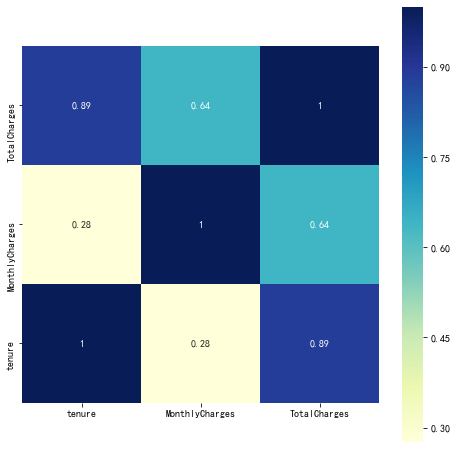

```python
nu_fea = data[['tenure', 'MonthlyCharges', 'TotalCharges']]    # 选择连续型数值特征计算相关系数
nu_fea = list(nu_fea)    # 特征名列表
pearson_mat = data[nu_fea].corr(method='spearman')    # 计算皮尔逊相关系数矩阵

plt.figure(figsize=(8,8)) # 建立图像

#seaborn.heatmap(data,square=False,annot=None,cmap=None)
#data:矩形数据集,square：布尔值，可选参数.如果为True，则将坐标轴方向设置为“equal”，以使每个单元格为方形.
#annot:布尔值或者矩形数据，可选参数.如果为True，则在每个热力图单元格中写入数据值。 如果数组的形状与data相同，则使用它来代替原始数据注释热力图
#cmap：matplotlib 颜色条名称或者对象，或者是颜色列表，可选参数.从数据值到颜色空间的映射。 如果没有提供，默认值将取决于是否设置了“center”
sns.heatmap(pearson_mat, square=True, annot=True, cmap="YlGnBu")    # 用热度图表示相关系数矩阵
####这句用于处理边界数字越界显示不全####
plt.ylim(0,len(pearson_mat))
plt.show() # 展示热度图
```

```python
data = data.drop(['TotalCharges'], axis=1)
data.head(5)    # 观察此时的数据集
```

|  | SeniorCitizen | Partner | Dependents | tenure | MultipleLines | OnlineSecurity | OnlineBackup | DeviceProtection | TechSupport | PaperlessBilling | MonthlyCharges | InternetService_DSL | InternetService_Fiber optic | InternetService_No | Contract_Month-to-month | Contract_One year | Contract_Two year | PaymentMethod_Bank transfer (automatic) | PaymentMethod_Credit card (automatic) | PaymentMethod_Electronic check | PaymentMethod_Mailed check | Churn |
| --- | --- | --- | --- | --- | --- | --- | --- | --- | --- | --- | --- | --- | --- | --- | --- | --- | --- | --- | --- | --- | --- | --- |
| 0 | 0 | 1 | 0 | -1.277445 | 0 | 0 | 1 | 0 | 0 | 1 | -1.160323 | 1 | 0 | 0 | 1 | 0 | 0 | 0 | 0 | 1 | 0 | 0 |
| 1 | 0 | 0 | 0 | 0.066327 | 0 | 1 | 0 | 1 | 0 | 0 | -0.259629 | 1 | 0 | 0 | 0 | 1 | 0 | 0 | 0 | 0 | 1 | 0 |
| 2 | 0 | 0 | 0 | -1.236724 | 0 | 1 | 1 | 0 | 0 | 1 | -0.362660 | 1 | 0 | 0 | 1 | 0 | 0 | 0 | 0 | 0 | 1 | 1 |
| 3 | 0 | 0 | 0 | 0.514251 | 0 | 1 | 0 | 1 | 1 | 0 | -0.746535 | 1 | 0 | 0 | 0 | 1 | 0 | 1 | 0 | 0 | 0 | 0 |
| 4 | 0 | 0 | 0 | -1.236724 | 0 | 0 | 0 | 0 | 0 | 1 | 0.197365 | 0 | 1 | 0 | 1 | 0 | 0 | 0 | 0 | 1 | 0 | 1 |

# 六、模型预测

### 1.类别不平衡问题的处理

前面我们观察到正负样本的比例大概在1:3左右，因此需要对正样本进行升采样或对负样本进行降采样。考虑到本数据集仅有7千多条样本，不适合采用降采样，进行升采样更为合理，本案例采用升采样中较为成熟的SMOTE方法生成更多的正样本。  
SMOTE方法：它以每个样本点的k个最近邻样本点为依据，随机的选择N个邻近点进行差值乘上一个[0,1]范围的阈值，从而达到合成数据的目的。

```python
# SMOTE方法代码
import random
from sklearn.neighbors import NearestNeighbors

class Smote:
    def __init__(self,samples,N,k):
        self.n_samples,self.n_attrs=samples.shape
        self.N=N
        self.k=k
        self.samples=samples
        self.newindex=0

    def over_sampling(self):
        N=int(self.N)
        self.synthetic = np.zeros((self.n_samples * N, self.n_attrs))
        neighbors=NearestNeighbors(n_neighbors=self.k).fit(self.samples)    # 1.对每个少数类样本均求其在所有少数类样本中的k近邻
        for i in range(len(self.samples)):
            nnarray=neighbors.kneighbors(self.samples[i].reshape(1,-1),return_distance=False)[0]
            self._populate(N,i,nnarray)
        return self.synthetic

    # 2.为每个少数类样本选择k个最近邻中的N个；3.并生成N个合成样本
    def _populate(self,N,i,nnarray):
        for j in range(N):
            nn=random.randint(0,self.k-1)
            dif=self.samples[nnarray[nn]]-self.samples[i]
            gap=random.random()
            self.synthetic[self.newindex]=self.samples[i]+gap*dif
            self.newindex+=1
```

```python
# 每个正样本用SMOTE方法随机生成两个新的样本
posDf = data[data['Churn'] == 1].drop(['Churn'], axis=1)    # 共1869条正样本, 取其所有特征列(把目标变量删掉)
posArray = posDf.values    # pd.DataFrame -> np.array, 以满足SMOTE方法的输入要求
newPosArray = Smote(posArray, 2, 5).over_sampling()
newPosDf = pd.DataFrame(newPosArray)    # np.array -> pd.DataFrame

newPosDf.head(10)    # 观察此时的新样本
```

|  | 0 | 1 | 2 | 3 | 4 | 5 | 6 | 7 | 8 | 9 | 10 | 11 | 12 | 13 | 14 | 15 | 16 | 17 | 18 | 19 | 20 |
| --- | --- | --- | --- | --- | --- | --- | --- | --- | --- | --- | --- | --- | --- | --- | --- | --- | --- | --- | --- | --- | --- |
| 0 | 0.000000 | 0.0 | 0.0 | -1.133085 | 0.0 | 0.151618 | 1.0 | 0.0 | 0.0 | 1.0 | -0.443021 | 1.0 | 0.0 | 0.0 | 1.0 | 0.0 | 0.0 | 0.0 | 0.0 | 0.0 | 1.0 |
| 1 | 0.000000 | 0.0 | 0.0 | -1.236724 | 0.0 | 1.000000 | 1.0 | 0.0 | 0.0 | 1.0 | -0.362660 | 1.0 | 0.0 | 0.0 | 1.0 | 0.0 | 0.0 | 0.0 | 0.0 | 0.0 | 1.0 |
| 2 | 0.000000 | 0.0 | 0.0 | -1.236724 | 0.0 | 0.000000 | 0.0 | 0.0 | 0.0 | 1.0 | 0.197365 | 0.0 | 1.0 | 0.0 | 1.0 | 0.0 | 0.0 | 0.0 | 0.0 | 1.0 | 0.0 |
| 3 | 0.000000 | 0.0 | 0.0 | -1.236724 | 0.0 | 0.000000 | 0.0 | 0.0 | 0.0 | 1.0 | 0.197365 | 0.0 | 1.0 | 0.0 | 1.0 | 0.0 | 0.0 | 0.0 | 0.0 | 1.0 | 0.0 |
| 4 | 0.000000 | 0.0 | 0.0 | -1.111792 | 1.0 | 0.000000 | 0.0 | 1.0 | 0.0 | 1.0 | 1.184882 | 0.0 | 1.0 | 0.0 | 1.0 | 0.0 | 0.0 | 0.0 | 0.0 | 1.0 | 0.0 |
| 5 | 0.000000 | 0.0 | 0.0 | -1.070933 | 1.0 | 0.000000 | 0.0 | 1.0 | 0.0 | 1.0 | 1.176211 | 0.0 | 1.0 | 0.0 | 1.0 | 0.0 | 0.0 | 0.0 | 0.0 | 1.0 | 0.0 |
| 6 | 0.000000 | 1.0 | 0.0 | -0.014733 | 1.0 | 0.000000 | 0.0 | 1.0 | 1.0 | 1.0 | 1.135588 | 0.0 | 1.0 | 0.0 | 1.0 | 0.0 | 0.0 | 0.0 | 0.0 | 1.0 | 0.0 |
| 7 | 0.000000 | 1.0 | 0.0 | -0.084564 | 1.0 | 0.000000 | 0.0 | 1.0 | 1.0 | 1.0 | 1.332236 | 0.0 | 1.0 | 0.0 | 1.0 | 0.0 | 0.0 | 0.0 | 0.0 | 1.0 | 0.0 |
| 8 | 0.534357 | 0.0 | 0.0 | 0.524818 | 1.0 | 0.000000 | 1.0 | 1.0 | 0.0 | 1.0 | 1.312799 | 0.0 | 1.0 | 0.0 | 1.0 | 0.0 | 0.0 | 1.0 | 0.0 | 0.0 | 0.0 |
| 9 | 0.000000 | 0.0 | 0.0 | 0.646966 | 1.0 | 0.000000 | 1.0 | 1.0 | 0.0 | 1.0 | 1.385255 | 0.0 | 1.0 | 0.0 | 1.0 | 0.0 | 0.0 | 1.0 | 0.0 | 0.0 | 0.0 |

```python
# 调整为正样本在数据集中应有的格式
newPosDf.columns = posDf.columns # 还原列名
# 将离散特征列的值变回0，1二元数值
cateCols = list(newPosDf.columns.drop(['tenure', 'MonthlyCharges']))
for i in cateCols:
    newPosDf[i] = newPosDf[i].apply(lambda x:1 if x>=0.5 else 0)
# 添加目标变量列
newPosDf['Churn'] = 1
newPosDf.head()
```

|  | SeniorCitizen | Partner | Dependents | tenure | MultipleLines | OnlineSecurity | OnlineBackup | DeviceProtection | TechSupport | PaperlessBilling | MonthlyCharges | InternetService_DSL | InternetService_Fiber optic | InternetService_No | Contract_Month-to-month | Contract_One year | Contract_Two year | PaymentMethod_Bank transfer (automatic) | PaymentMethod_Credit card (automatic) | PaymentMethod_Electronic check | PaymentMethod_Mailed check | Churn |
| --- | --- | --- | --- | --- | --- | --- | --- | --- | --- | --- | --- | --- | --- | --- | --- | --- | --- | --- | --- | --- | --- | --- |
| 0 | 0 | 0 | 0 | -1.133085 | 0 | 0 | 1 | 0 | 0 | 1 | -0.443021 | 1 | 0 | 0 | 1 | 0 | 0 | 0 | 0 | 0 | 1 | 1 |
| 1 | 0 | 0 | 0 | -1.236724 | 0 | 1 | 1 | 0 | 0 | 1 | -0.362660 | 1 | 0 | 0 | 1 | 0 | 0 | 0 | 0 | 0 | 1 | 1 |
| 2 | 0 | 0 | 0 | -1.236724 | 0 | 0 | 0 | 0 | 0 | 1 | 0.197365 | 0 | 1 | 0 | 1 | 0 | 0 | 0 | 0 | 1 | 0 | 1 |
| 3 | 0 | 0 | 0 | -1.236724 | 0 | 0 | 0 | 0 | 0 | 1 | 0.197365 | 0 | 1 | 0 | 1 | 0 | 0 | 0 | 0 | 1 | 0 | 1 |
| 4 | 0 | 0 | 0 | -1.111792 | 1 | 0 | 0 | 1 | 0 | 1 | 1.184882 | 0 | 1 | 0 | 1 | 0 | 0 | 0 | 0 | 1 | 0 | 1 |

```python
print("原本的正样本有%d条" % posDf.shape[0])
print("原本的负样本有%d条" % (data.shape[0] - posDf.shape[0]))
```

```
原本的正样本有1869条
原本的负样本有5174条
```

为保证正负样本平衡，从新生成的样本中取出（5174 - 1869 = 3305）条样本，并加入原数据集进行shuffle操作。

```python
# 构建类别平衡的数据集
from sklearn.utils import shuffle

newPosDf = newPosDf[:3305]    # 直接选取前3305条样本
data = pd.concat([data, newPosDf])    # 竖向拼接
# data = shuffle(data).reset_index(drop=True)

print("此时数据集的规模为：", data.shape)
```

```
此时数据集的规模为： (10348, 22)
```

### 2.交叉验证

在使用训练集对参数进行训练的时候，经常会发现人们通常会将一整个训练集分为三个部分（比如mnist手写训练集）。一般分为：训练集（train_set），评估集（valid_set），测试集（test_set）这三个部分。这其实是为了保证训练效果而特意设置的。其中测试集很好理解，其实就是完全不参与训练的数据，仅仅用来观测测试效果的数据。而训练集和评估集则牵涉到下面的知识了。  
因为在实际的训练中，训练的结果对于训练集的拟合程度通常还是挺好的（初始条件敏感），但是对于训练集之外的数据的拟合程度通常就不那么令人满意了。因此我们通常并不会把所有的数据集都拿来训练，而是分出一部分来（这一部分不参加训练）对训练集生成的参数进行测试，相对客观的判断这些参数对训练集之外的数据的符合程度。这种思想就称为交叉验证（Cross Validation）

同样考虑到样本数较少的问题，本案例采用K折交叉验证的方式进行预测，提高数据利用率；此外，采用逻辑回归、SVM、随机森林、AdaBoost、XGBoost等算法构建模型，从中选择预测效果较好的模型进行最终的预测。

```python
# K折交叉验证代码
# from sklearn.cross_validation import KFold
from sklearn.model_selection import KFold

def kFold_cv(X, y, classifier, **kwargs):
    """
    :param X: 特征
    :param y: 目标变量
    :param classifier: 分类器
    :param **kwargs: 参数
    :return: 预测结果
    """
    kf = KFold(n_splits=5, shuffle=True)
    y_pred = np.zeros(len(y))    # 初始化y_pred数组

    for train_index, test_index in kf.split(X):
        X_train = X[train_index]
        X_test = X[test_index]
        y_train = y[train_index]    # 划分数据集
        clf = classifier(**kwargs)
        clf.fit(X_train, y_train)    # 模型训练
        y_pred[test_index] = clf.predict(X_test)    # 模型预测

    return y_pred
```

```python
# 模型预测
from sklearn.linear_model import LogisticRegression as LR    # 逻辑回归
from sklearn.svm import SVC    # SVM
from sklearn.ensemble import RandomForestClassifier as RF    # 随机森林
from sklearn.ensemble import AdaBoostClassifier as Adaboost    # AdaBoost
from xgboost import XGBClassifier as XGB    # XGBoost

# X = data.iloc[:, :-1].as_matrix()
X = data.iloc[:, :-1].iloc[:,:].values # Kagging
y = data.iloc[:, -1].values

# 此处仅做演示，因此未进行调参过程
lr_pred = kFold_cv(X, y, LR)
svc_pred = kFold_cv(X, y, SVC)
rf_pred = kFold_cv(X, y, RF)
ada_pred = kFold_cv(X, y, Adaboost)
xgb_pred = kFold_cv(X, y, XGB)
```

[output not shown]

# 七、模型评估

对于本案例，精确率代表的意义是：在所有我们预测为流失的样本中，真正流失的样本数；  
召回率代表的意义则是：在真正流失的样本中，我们预测到多少条样本。  
很明显，召回率是运营商们关心的指标，即宁可把未流失的客户预测为流失客户而进行多余的留客行为，也不漏掉任何一名真正流失的客户。  
本案例依旧采取精确率、召回率以及综合两者的F1值，但关注的重点仍然放在召回率上。

```python
from sklearn.metrics import precision_score, recall_score, f1_score    # 导入精确率、召回率、F1值等评价指标

scoreDf = pd.DataFrame(columns=['LR', 'SVC', 'RandomForest', 'AdaBoost', 'XGBoost'])
pred = [lr_pred, svc_pred, rf_pred, ada_pred, xgb_pred]
for i in range(5):
    r = recall_score(y, pred[i])
    p = precision_score(y, pred[i])
    f1 = f1_score(y, pred[i])
    scoreDf.iloc[:, i] = pd.Series([r, p, f1])

scoreDf.index = ['Recall', 'Precision', 'F1-score']
scoreDf
```

|  | LR | SVC | RandomForest | AdaBoost | XGBoost |
| --- | --- | --- | --- | --- | --- |
| Recall | 0.797062 | 0.804600 | 0.859296 | 0.823154 | 0.851372 |
| Precision | 0.749001 | 0.742862 | 0.827779 | 0.751014 | 0.813331 |
| F1-score | 0.772285 | 0.772500 | 0.843243 | 0.785431 | 0.831917 |

由表可知：五种模型中RandomForest的效果最好，可以用RandomForest单模型进行预测，也可以采用召回率最高的RandomForest和XGBoost进行加权平均融合或Stacking融合。本案例选用RandomForest单模型进行演示，该算法还能同时输出特征重要性。

```python
# 特征重要性
X = data.iloc[:, :-1].values #除了倒数第一列以外的所有
y = data.iloc[:, -1].values #倒数第一列

kf = KFold(n_splits=5, shuffle=True, random_state=0)
y_pred = np.zeros(len(y))    # 初始化y_pred数组
clf = RF()

for train_index, test_index in kf.split(X):
    X_train = X[train_index]
    X_test = X[test_index]
    y_train = y[train_index]    # 划分数据集
    clf.fit(X_train, y_train)    # 模型训练
    y_pred[test_index] = clf.predict(X_test)    # 模型预测

feature_importances = pd.DataFrame(clf.feature_importances_,
                                   index = data.columns.drop(['Churn']),
                                    columns=['importance']).sort_values('importance', ascending=False)
feature_importances    # 查看特征重要性
```

|  | importance |
| --- | --- |
| tenure | 0.277496 |
| MonthlyCharges | 0.248952 |
| Contract_Month-to-month | 0.060676 |
| Contract_Two year | 0.039968 |
| PaperlessBilling | 0.033974 |
| PaymentMethod_Electronic check | 0.033332 |
| TechSupport | 0.029672 |
| Partner | 0.028046 |
| InternetService_Fiber optic | 0.026992 |
| OnlineSecurity | 0.024690 |
| OnlineBackup | 0.024628 |
| Dependents | 0.024379 |
| MultipleLines | 0.023968 |
| DeviceProtection | 0.022592 |
| SeniorCitizen | 0.020134 |
| InternetService_No | 0.016855 |
| PaymentMethod_Credit card (automatic) | 0.014499 |
| PaymentMethod_Bank transfer (automatic) | 0.013430 |
| Contract_One year | 0.012715 |
| InternetService_DSL | 0.012450 |
| PaymentMethod_Mailed check | 0.010553 |

# 八、分析决策

### 1.用户画像

根据用户画像，可以从各个方面推出相应活动以求留下可能流失的客户：

- 对老人推出亲情套餐等优惠
- 对未婚、无家属的客户推出暖心套餐等优惠
- 对新入网用户提供一定时期的优惠活动，直至客户到达稳定期
- 提高电话服务、光纤网络、网络电视、网络电影等的客户体验，尝试提高用户的留存率，避免客户流失
- 对能够帮助客户留存的在线安全、在线备份、设备保护、技术支持等互联网增值业务，加大宣传推广力度
- 对逐月付费用户推出年费优惠活动
- 对使用电子结算、电子支票的客户，推出其他支付方式的优惠活动
- 对每月费用在70～110之间推出一定的优惠活动

### 2.结合模型

在模型预测阶段，可以结合预测出的概率值决定对哪些客户进行重点留存：

```python
# 预测客户流失的概率值
def prob_cv(X, y, classifier, **kwargs):
    """
    :param X: 特征
    :param y: 目标变量
    :param classifier: 分类器
    :param **kwargs: 参数
    :return: 预测结果
    """
    kf = KFold(n_splits=5, random_state=0)
    y_pred = np.zeros(len(y))

    for train_index, test_index in kf.split(X):
        X_train = X[train_index]
        X_test = X[test_index]
        y_train = y[train_index]
        clf = classifier(**kwargs)
        clf.fit(X_train, y_train)
        y_pred[test_index] = clf.predict_proba(X_test)[:,1]    # 注：此处预测的是概率值

    return y_pred
```

```python
prob = prob_cv(X, y, RF)    # 预测概率值
prob = np.round(prob, 1)    # 对预测出的概率值保留一位小数，便于分组观察

# 合并预测值和真实值
probDf = pd.DataFrame(prob)
churnDf = pd.DataFrame(y)
df1 = pd.concat([probDf, churnDf], axis=1)
df1.columns = ['prob', 'churn']

df1 = df1[:7043]    # 只取原始数据集的7043条样本进行决策
df1.head(10)
```

|  | prob | churn |
| --- | --- | --- |
| 0 | 0.9 | 0 |
| 1 | 0.0 | 0 |
| 2 | 1.0 | 1 |
| 3 | 0.1 | 0 |
| 4 | 1.0 | 1 |
| 5 | 1.0 | 1 |
| 6 | 0.6 | 0 |
| 7 | 0.4 | 0 |
| 8 | 1.0 | 1 |
| 9 | 0.0 | 0 |

```python
# 分组计算每种预测概率值所对应的真实流失率
group = df1.groupby(['prob'])
cnt = group.count()    # 每种概率值对应的样本数
true_prob = group.sum() / group.count()    # 真实流失率
df2 = pd.concat([cnt,true_prob], axis=1).reset_index()
df2.columns = ['prob', 'cnt', 'true_prob']

df2
```

|  | prob | cnt | true_prob |
| --- | --- | --- | --- |
| 0 | 0.0 | 1676 | 0.006563 |
| 1 | 0.1 | 787 | 0.030496 |
| 2 | 0.2 | 579 | 0.055268 |
| 3 | 0.3 | 482 | 0.085062 |
| 4 | 0.4 | 439 | 0.143508 |
| 5 | 0.5 | 411 | 0.189781 |
| 6 | 0.6 | 421 | 0.285036 |
| 7 | 0.7 | 375 | 0.405333 |
| 8 | 0.8 | 472 | 0.533898 |
| 9 | 0.9 | 558 | 0.729391 |
| 10 | 1.0 | 843 | 0.817319 |

由表可知：预测流失率越大的客户中越有可能真正发生流失。  
对运营商而言，可以根据各预测概率值分组的真实流失率设定阈值进行决策。  
例如，假设阈值为true_prob = 0.6，即优先关注真正流失为60%以上的群体，也就表示运营商可以对预测结果中大于等于0.9的客户进行重点留存。

# 九、优化思路

- 数据
  - 数据预处理：对缺失值、异常值进行预处理
  - 数据分析：用箱型图、饼图等
  - 数据类别不平衡处理：SMOTE方法进行升采样
- 模型
  - 模型评估：交叉验证方法
  - 逻辑回归、SVM、随机森林、AdaBoost、XGBoost等